# Customer Status Prediction

Bartu Paçal, Begüm Başovalı

2025-12-29

# **Customer Status Prediction - Test Phase**

This document performs predictions on test data using pre-trained machine learning models for customer status classification.

# **0) Setup**

**Purpose:** Initialize the environment, clear workspace, set seed for reproducibility, define project paths, and load required libraries.

```r
# Clear workspace and set random seed for reproducibility
rm(list = ls())
set.seed(42)

# Define project directories
PROJECT_DIR <- "C:/Users/Bartu/Desktop/Customer_Status_Prediction"
DATA_DIR <- file.path(PROJECT_DIR, "Test Datasets")

# Load required libraries
library(dplyr)        # Data manipulation
library(tidyr)        # Data tidying
library(caret)        # Machine learning toolkit
library(ggplot2)      # Visualization
library(randomForest) # Random Forest model
library(nnet)         # Neural networks
library(gbm)          # Gradient Boosting Machine
library(knitr)        # R Markdown support
library(kableExtra)   # Enhanced tables

cat("=========================================================\n")
cat("CUSTOMER STATUS PREDICTION - TEST PHASE\n")
```

```
## CUSTOMER STATUS PREDICTION - TEST PHASE
```

```r
cat("=========================================================\n")
```

# **1) Load Trained Models**

**Purpose:** Load pre-trained machine learning models and preprocessing objects from the training phase.

**Expected objects:** - `rf_model`: Random Forest model - `log_model`: Logistic Regression model - `gbm_model`: Gradient Boosting Machine model - `dummies`: One-hot encoding object (dummyVars) - `train_final`: Training data structure for column alignment

```r
cat("\nLoading train models...\n")
```

```
##
## Loading train models...
```

```r
if (!file.exists(file.path(PROJECT_DIR, "train_models_final.RData"))) {
  stop("ERROR: train_models_final.RData not found! Run train.R script first.")
}

load(file.path(PROJECT_DIR, "train_models_final.RData"))

cat("Models loaded:\n")
```

```
## Models loaded:
```

```r
cat("   - Random Forest:", ifelse(exists("rf_model"), "OK", "X"), "\n")
```

```
##    - Random Forest: OK
```

```r
cat("   - Logistic Regression:", ifelse(exists("log_model"), "OK", "X"), "\n")
```

```
##    - Logistic Regression: OK
```

```r
cat("   - GBM:", ifelse(exists("gbm_model"), "OK", "X"), "\n")
```

```
##    - GBM: OK
```

```r
cat("   - Dummies object:", ifelse(exists("dummies"), "OK", "X"), "\n")
```

```
##    - Dummies object: OK
```

# **2) Read Test Data**

**Purpose:** Load all test CSV files from the data directory.

**Test datasets:** 1. Customer status and level 2. Demographics information 3. Monthly recurring revenue (MRR) 4. Region and industry data 5. Revenue history 6. Satisfaction scores 7. Newsletter engagement 8. Product bug reports 9. Support ticket activity

```r
cat("\nReading test data...\n")
```

```
##
## Reading test data...
```

```r
# Helper function to read CSV files
read_test_file <- function(file_name) {
  read.csv(file.path(DATA_DIR, file_name), stringsAsFactors = FALSE)
}

# Define test file names
test_files <- list(
  status = "customer_status_level_test.csv",
  demographics = "customer_demographics_test.csv",
  revenue = "customer_monthly_recurring_revenue_test.csv",
  region = "customer_region_and_industry_test.csv",
  history = "customer_revenue_history_test.csv",
  satisfaction = "customer_satisfaction_scores_test.csv",
  engagement = "newsletter_engagement_test.csv",
  bug = "product_bug_reports_test.csv",
  ticket = "support_ticket_activity_test.csv"
)

# Read all test files
test_data <- lapply(test_files, read_test_file)
names(test_data) <- c(
  "Customer_Status_Test", "Customer_Demographics_Test", "Customer_Revenue_Test",
  "Customer_Region_Industry_Test", "Customer_Revenue_History_Test",
  "Customer_Satisfaction_Test", "Customer_Engagement_Test",
  "Customer_Bug_Reports_Test", "Customer_Ticket_Activity_Test"
)

# Assign to global environment
list2env(test_data, envir = .GlobalEnv)
```

```
## <environment: R_GlobalEnv>
```

```r
cat("Test files loaded.\n")
```

```
## Test files loaded.
```

# **3) Data Preparation**

**Purpose:** Standardize column names and handle the target variable.

**Operations:** - Check for Status column (should not exist in test data) - Save Customer.Level if present - Standardize ID column names across datasets

```r
cat("\nData preparation...\n")
```

```
##
## Data preparation...
```

```r
# Check column names in Customer_Status_Test
cat("Checking Customer_Status_Test columns:\n")
```

```
## Checking Customer_Status_Test columns:
```

```r
print(names(Customer_Status_Test))
```

```
## [1] "Customer.ID"    "Customer.Level" "Status"
```

```r
# Check if Status column exists in test data
if ("Status" %in% names(Customer_Status_Test)) {
  # Save Customer.Level for merging
  if ("Customer.Level" %in% names(Customer_Status_Test)) {
    customer_level_backup <- Customer_Status_Test %>%
      select(Customer.ID, Customer.Level)
    cat("Customer.Level saved for merging.\n")
  }

  # Remove Status column (target variable)
  Customer_Status_Test <- Customer_Status_Test %>%
    select(-Status)
  cat("Status column removed (target variable).\n")
} else {
  cat("Note: Status column not found in test data (expected).\n")

  # Still check for Customer.Level
  if ("Customer.Level" %in% names(Customer_Status_Test)) {
    customer_level_backup <- Customer_Status_Test %>%
      select(Customer.ID, Customer.Level)
    cat("Customer.Level saved for merging.\n")
  }
}
```

```
## Customer.Level saved for merging.
## Status column removed (target variable).
```

```r
# Standardize ID column
if ("CUS.ID" %in% names(Customer_Demographics_Test)) {
  Customer_Demographics_Test <- Customer_Demographics_Test %>%
    rename(Customer.ID = CUS.ID)
  cat("ID column standardized.\n")
}
```

```
## ID column standardized.
```

# **4) Data Aggregation**

**Purpose:** Aggregate customer-level data from multiple sources. This matches the aggregation performed during training.

## 4.1 Bug Reports Aggregation

Sum all bug reports per customer.

```r
cat("\nTest data aggregation...\n")
```

```
##
## Test data aggregation...
```

```r
# Helper function for mode calculation
get_mode_chr <- function(x) {
  x <- x[!is.na(x)]
  if (length(x) == 0) return(NA_character_)
  tb <- sort(table(x), decreasing = TRUE)
  names(tb)[1]
}

# Aggregate bug reports
Customer_Bug_Reports_Test_Agg <- Customer_Bug_Reports_Test %>%
  group_by(Customer.ID) %>%
  summarise(
    Total_Bug_Count = sum(Product.Bug.Task.Count, na.rm = TRUE),
    .groups = "drop"
  )
```

## 4.2 Satisfaction Scores Aggregation

Aggregate survey responses: calculate means for numeric scores, find mode for categorical variables, and extract last survey date.

```r
# Check column names first
cat("Original Customer_Satisfaction_Test columns:\n")
```

```
## Original Customer_Satisfaction_Test columns:
```

```r
print(names(Customer_Satisfaction_Test))
```

```
##  [1] "Customer.ID"
##  [2] "Year"
##  [3] "Quarter"
##  [4] "Survey.Date"
##  [5] "Response.Date"
##  [6] "How.likely.are.you.to.recommend.insider.to.a.friend.or.colleague"
##  [7] "How.would.you.rate.the.value.you.gain.from.our.company"
##  [8] "How.frequently.are.you.using.our.platform"
##  [9] "Please.rate.the.overall.quality.of.our.products"
## [10] "Please.rate.the.usability.of.the.panel"
## [11] "Please.rate.your.understanding.of.our.reporting.capabilities.in.the.panel"
```

```r
# Standardize column names
if (ncol(Customer_Satisfaction_Test) >= 11) {
  names(Customer_Satisfaction_Test)[1:11] <- c(
    "Customer.ID", "Year", "Quarter", "Survey_Date", "Response_Date",
    "NPS", "Value_Score", "Usage_Freq", "Quality_Score",
    "Usability_Score", "Reporting_Score"
  )

  Customer_Satisfaction_Test <- Customer_Satisfaction_Test %>%
    mutate(
      Survey_Date = as.Date(Survey_Date),
      Response_Date = as.Date(Response_Date)
    )

  # Get last survey records
  last_rows_test <- Customer_Satisfaction_Test %>%
    mutate(last_date = coalesce(Survey_Date, Response_Date)) %>%
    arrange(Customer.ID, last_date) %>%
    group_by(Customer.ID) %>%
    slice_tail(n = 1) %>%
    ungroup() %>%
    select(Customer.ID, Year, Quarter, Survey_Date, Response_Date)

  # Aggregate satisfaction data
  Customer_Satisfaction_Test_Agg <- Customer_Satisfaction_Test %>%
    group_by(Customer.ID) %>%
    summarise(
      NPS_mean = mean(NPS, na.rm = TRUE),
      Value_mean = mean(Value_Score, na.rm = TRUE),
      Quality_mean = mean(Quality_Score, na.rm = TRUE),
      Usability_mean = mean(Usability_Score, na.rm = TRUE),
      Reporting_score = get_mode_chr(Reporting_Score),
      Usage_Freq = get_mode_chr(Usage_Freq),
      Survey_count = n(),
      .groups = "drop"
    ) %>%
    left_join(
      last_rows_test %>%
        rename(
          Year_Last = Year,
          Quarter_Last = Quarter,
          Last_Survey_Date = Survey_Date,
          Last_Response_Date = Response_Date
        ),
      by = "Customer.ID"
    )
} else {
  cat("Warning: Customer_Satisfaction_Test has unexpected number of columns\n")
  Customer_Satisfaction_Test_Agg <- data.frame(Customer.ID = unique(Customer_Satisfaction_Test$Customer.ID))
}
```

## 4.3 Support Ticket Activity Aggregation

Aggregate support tickets per customer.

```r
if ("Customer.ID" %in% names(Customer_Ticket_Activity_Test)) {
  Customer_Ticket_Activity_Test_Agg <- if (sum(duplicated(Customer_Ticket_Activity_Test$Customer.ID)) > 0) {
    Customer_Ticket_Activity_Test %>%
      group_by(Customer.ID) %>%
      summarise(
        Help.Ticket.Count = sum(Help.Ticket.Count, na.rm = TRUE),
        Help.Ticket.Lead.Time..hours. = mean(Help.Ticket.Lead.Time..hours., na.rm = TRUE),
        .groups = "drop"
      )
  } else {
    Customer_Ticket_Activity_Test
  }
} else {
  cat("Warning: Customer.ID not found in Ticket Activity data\n")
  Customer_Ticket_Activity_Test_Agg <- data.frame()
}
```

## 4.4 Newsletter Engagement Aggregation

Sum newsletter interactions per customer.

```r
if ("Customer.ID" %in% names(Customer_Engagement_Test)) {
  Customer_Engagement_Test_Agg <- if (sum(duplicated(Customer_Engagement_Test$Customer.ID)) > 0) {
    Customer_Engagement_Test %>%
      group_by(Customer.ID) %>%
      summarise(
        Company.Newsletter.Interaction.Count = sum(Company.Newsletter.Interaction.Count, na.rm = TRUE),
        .groups = "drop"
      )
  } else {
    Customer_Engagement_Test
  }
} else {
  cat("Warning: Customer.ID not found in Engagement data\n")
  Customer_Engagement_Test_Agg <- data.frame()
}

cat("Aggregation completed.\n")
```

```
## Aggregation completed.
```

# **5) Merge Test Data**

**Purpose:** Combine all aggregated datasets into a single master test dataset using left joins on Customer.ID.

```r
cat("\nMerging test data...\n")
```

```
##
## Merging test data...
```

```r
# Start with Customer_Status_Test
master_test <- Customer_Status_Test

# List of dataframes to merge
data_to_merge <- list(
  Customer_Demographics_Test,
  Customer_Revenue_Test,
  Customer_Region_Industry_Test,
  Customer_Revenue_History_Test,
  Customer_Satisfaction_Test_Agg,
  Customer_Engagement_Test_Agg,
  Customer_Bug_Reports_Test_Agg,
  Customer_Ticket_Activity_Test_Agg
)

# Merge all dataframes
for (i in seq_along(data_to_merge)) {
  df_name <- c("Demographics", "Revenue", "Region_Industry", "Revenue_History",
               "Satisfaction", "Engagement", "Bug_Reports", "Ticket_Activity")[i]

  if (nrow(data_to_merge[[i]]) > 0 && "Customer.ID" %in% names(data_to_merge[[i]])) {
    master_test <- master_test %>%
      left_join(data_to_merge[[i]], by = "Customer.ID")
    cat("Merged:", df_name, "\n")
  } else {
    cat("Skipped:", df_name, "(no data or missing Customer.ID)\n")
  }
}
```

```
## Merged: Demographics
## Merged: Revenue
## Merged: Region_Industry
## Merged: Revenue_History
## Merged: Satisfaction
## Merged: Engagement
## Merged: Bug_Reports
## Merged: Ticket_Activity
```

```r
cat("Test data merged. Total customers:", nrow(master_test), "\n")
```

```
## Test data merged. Total customers: 619
```

```r
if (exists("customer_level_backup")) {
  cat("Customer.Level column preserved.\n")
}
```

```
## Customer.Level column preserved.
```

# **6) Basic Data Cleaning**

**Purpose:** Clean and standardize data types. This must match the cleaning performed on training data.

**Operations:** - Clean currency columns (remove $ and ,) - Convert categorical variables to factors - Convert date columns to Date type

```r
cat("\nTest data cleaning...\n")
```

```
##
## Test data cleaning...
```

```r
# Clean currency columns
currency_columns <- c("MRR", "Total.Revenue")
for (col in currency_columns) {
  if (col %in% colnames(master_test)) {
    master_test[[col]] <- as.numeric(gsub("[\\$,]", "", as.character(master_test[[col]])))
    cat("Cleaned currency column:", col, "\n")
  }
}
```

```
## Cleaned currency column: MRR
## Cleaned currency column: Total.Revenue
```

```r
# Factor conversions
factor_columns <- c("Region", "Customer.Level", "Vertical", "Subvertical",
                    "Usage_Freq", "Reporting_score")
for (col in factor_columns) {
  if (col %in% colnames(master_test)) {
    master_test[[col]] <- as.factor(master_test[[col]])
    cat("Converted to factor:", col, "\n")
  }
}
```

```
## Converted to factor: Region
## Converted to factor: Customer.Level
## Converted to factor: Vertical
## Converted to factor: Subvertical
## Converted to factor: Usage_Freq
## Converted to factor: Reporting_score
```

```r
# Date conversions
date_columns <- c("Last_Survey_Date", "Last_Response_Date")
for (col in date_columns) {
  if (col %in% colnames(master_test)) {
    master_test[[col]] <- as.Date(master_test[[col]])
    cat("Converted to date:", col, "\n")
  }
}
```

```
## Converted to date: Last_Survey_Date
## Converted to date: Last_Response_Date
```

```r
cat("Basic cleaning completed.\n")
```

```
## Basic cleaning completed.
```

# **7) Feature Engineering**

**Purpose:** Create new features and handle missing values. **Critical:** This must exactly match the feature engineering from training.

## 7.1 Missing Value Handling

Create NA flags and impute missing values.

```r
cat("\nFeature Engineering - Test Data...\n")
```

```
##
## Feature Engineering - Test Data...
```

```r
# MRR missing values
if ("MRR" %in% colnames(master_test)) {
  master_test$MRR_na_flag <- as.integer(is.na(master_test$MRR))
  master_test$MRR[is.na(master_test$MRR)] <- 0
  cat("Processed MRR missing values\n")
}
```

```
## Processed MRR missing values
```

```r
# Total Revenue missing values
if ("Total.Revenue" %in% colnames(master_test)) {
  master_test$Total.Revenue_na_flag <- as.integer(is.na(master_test$Total.Revenue))
  master_test$Total.Revenue[is.na(master_test$Total.Revenue)] <- 0
  cat("Processed Total.Revenue missing values\n")
}
```

```
## Processed Total.Revenue missing values
```

```r
# Customer Age missing values
if ("Customer.Age..Months." %in% colnames(master_test)) {
  master_test$Customer.Age..Months.[is.na(master_test$Customer.Age..Months.)] <-
    median(master_test$Customer.Age..Months., na.rm = TRUE)
  cat("Processed Customer.Age..Months. missing values\n")
}
```

```
## Processed Customer.Age..Months. missing values
```

## 7.2 Survey Score Processing

Create survey flag and impute survey-related missing values.

```r
# Survey existence flag
if ("NPS_mean" %in% colnames(master_test)) {
  master_test$has_survey <- ifelse(is.na(master_test$NPS_mean), 0, 1)
  cat("Created has_survey flag\n")
}
```

```
## Created has_survey flag
```

```r
# Impute survey variables
survey_vars <- c("NPS_mean", "Value_mean", "Quality_mean", "Usability_mean")
for (var in survey_vars) {
  if (var %in% colnames(master_test)) {
    master_test[[var]][is.na(master_test[[var]])] <- median(master_test[[var]], na.rm = TRUE)
    cat("Imputed missing values for:", var, "\n")
  }
}
```

```
## Imputed missing values for: NPS_mean
## Imputed missing values for: Value_mean
## Imputed missing values for: Quality_mean
## Imputed missing values for: Usability_mean
```

## 7.3 Categorical Variable Processing

Replace NA with “None” for categorical variables.

```r
if ("Reporting_score" %in% colnames(master_test)) {
  master_test <- master_test %>%
    mutate(
      Reporting_score = replace_na(as.character(Reporting_score), "None")
    )
  cat("Processed Reporting_score NA values\n")
}
```

```
## Processed Reporting_score NA values
```

```r
if ("Usage_Freq" %in% colnames(master_test)) {
  master_test <- master_test %>%
    mutate(
      Usage_Freq = replace_na(as.character(Usage_Freq), "None")
    )
  cat("Processed Usage_Freq NA values\n")
}
```

```
## Processed Usage_Freq NA values
```

```r
# Survey count
if ("Survey_count" %in% colnames(master_test)) {
  master_test$Survey_count[is.na(master_test$Survey_count)] <- 0
  cat("Processed Survey_count NA values\n")
}
```

```
## Processed Survey_count NA values
```

## 7.4 Response Delay Features

Calculate response delay and create no-response flag.

```r
if (all(c("Last_Response_Date", "Last_Survey_Date") %in% colnames(master_test))) {
  master_test$no_response_flag <- ifelse(
    is.na(master_test$Last_Response_Date) | is.na(master_test$Last_Survey_Date), 1, 0
  )

  master_test$response_delay_days <- as.numeric(master_test$Last_Response_Date - master_test$Last_Survey_Date)
  master_test$response_delay_days[is.na(master_test$response_delay_days)] <- 0
  master_test$response_delay_days[master_test$response_delay_days < 0] <- 0
  cat("Created response delay features\n")
}
```

```
## Created response delay features
```

## 7.5 Interaction Flags

Create existence flags for newsletter, bugs, and tickets.

```r
# Newsletter interaction
if ("Company.Newsletter.Interaction.Count" %in% colnames(master_test)) {
  master_test$has_newsletter_interaction <- ifelse(is.na(master_test$Company.Newsletter.Interaction.Count), 0, 1)
  master_test$Company.Newsletter.Interaction.Count[is.na(master_test$Company.Newsletter.Interaction.Count)] <- 0
  cat("Processed newsletter features\n")
}
```

```
## Processed newsletter features
```

```r
# Bug reports
if ("Total_Bug_Count" %in% colnames(master_test)) {
  master_test$has_bug_report <- ifelse(is.na(master_test$Total_Bug_Count), 0, 1)
  master_test$Total_Bug_Count[is.na(master_test$Total_Bug_Count)] <- 0
  cat("Processed bug report features\n")
}
```

```
## Processed bug report features
```

```r
# Support tickets
if ("Help.Ticket.Count" %in% colnames(master_test)) {
  master_test$has_ticket <- ifelse(is.na(master_test$Help.Ticket.Count), 0, 1)
  master_test$Help.Ticket.Count[is.na(master_test$Help.Ticket.Count)] <- 0
  cat("Processed ticket features\n")
}
```

```
## Processed ticket features
```

```r
if ("Help.Ticket.Lead.Time..hours." %in% colnames(master_test)) {
  master_test$Help.Ticket.Lead.Time..hours.[is.na(master_test$Help.Ticket.Lead.Time..hours.)] <- 0
  cat("Processed ticket lead time\n")
}
```

```
## Processed ticket lead time
```

## 7.6 Advanced Engineered Features

Create composite metrics that combine multiple variables.

```r
cat("\nCreating new features...\n")
```

```
##
## Creating new features...
```

```r
# 1) Satisfaction Composite Score
if (all(c("NPS_mean", "Value_mean", "Quality_mean", "Usability_mean") %in% colnames(master_test))) {
  master_test$Satisfaction_Composite <- rowMeans(
    master_test[, c("NPS_mean", "Value_mean", "Quality_mean", "Usability_mean")],
    na.rm = TRUE
  )
  cat("Created Satisfaction_Composite feature\n")
}
```

```
## Created Satisfaction_Composite feature
```

```r
# 2) Support Burden (weighted by lead time)
if (all(c("Help.Ticket.Count", "Help.Ticket.Lead.Time..hours.") %in% colnames(master_test))) {
  master_test$Support_Burden <- master_test$Help.Ticket.Count *
    ifelse(master_test$Help.Ticket.Lead.Time..hours. > 0,
           master_test$Help.Ticket.Lead.Time..hours., 1)
  cat("Created Support_Burden feature\n")
}
```

```
## Created Support_Burden feature
```

```r
# 3) Revenue Efficiency (revenue per month of tenure)
if (all(c("Total.Revenue", "Customer.Age..Months.") %in% colnames(master_test))) {
  master_test$Revenue_per_Month <- ifelse(
    master_test$Customer.Age..Months. > 0,
    master_test$Total.Revenue / master_test$Customer.Age..Months.,
    0
  )
  cat("Created Revenue_per_Month feature\n")
}
```

```
## Created Revenue_per_Month feature
```

```r
# 4) Bug Frequency (bugs per month of tenure)
if (all(c("Total_Bug_Count", "Customer.Age..Months.") %in% colnames(master_test))) {
  master_test$Bug_Frequency <- ifelse(
    master_test$Customer.Age..Months. > 0,
    master_test$Total_Bug_Count / master_test$Customer.Age..Months.,
    0
  )
  cat("Created Bug_Frequency feature\n")
}
```

```
## Created Bug_Frequency feature
```

```r
# 5) Engagement Ratio (newsletter interactions per month)
if (all(c("Company.Newsletter.Interaction.Count", "Customer.Age..Months.") %in% colnames(master_test))) {
  master_test$Engagement_Ratio <- ifelse(
    master_test$Customer.Age..Months. > 0,
    master_test$Company.Newsletter.Interaction.Count / master_test$Customer.Age..Months.,
    0
  )
  cat("Created Engagement_Ratio feature\n")
}
```

```
## Created Engagement_Ratio feature
```

```r
# 6) MRR to Total Revenue Ratio
if (all(c("MRR", "Total.Revenue") %in% colnames(master_test))) {
  master_test$MRR_Ratio <- ifelse(
    master_test$Total.Revenue > 0,
    master_test$MRR / master_test$Total.Revenue,
    0
  )
  cat("Created MRR_Ratio feature\n")
}
```

```
## Created MRR_Ratio feature
```

```r
cat("Feature engineering completed.\n")
```

```
## Feature engineering completed.
```

# **8) Prepare Data for Modeling**

**Purpose:** Remove non-predictive columns and align with training data structure.

```r
cat("\nPreparing data for model...\n")
```

```
##
## Preparing data for model...
```

```r
# Save Customer IDs for submission
test_customer_ids <- master_test$Customer.ID

# Remove ID and date variables
master_test_model <- master_test %>%
  select(-Customer.ID)

# Remove date variables if they exist
date_vars <- c("Last_Survey_Date", "Last_Response_Date")
master_test_model <- master_test_model %>%
  select(-any_of(date_vars))

# Remove variables that were removed in train
variables_to_remove <- c(
  "NPS_mean", "Value_mean", "Quality_mean", "Usability_mean",
  "Help.Ticket.Count", "Help.Ticket.Lead.Time..hours."
)

master_test_model <- master_test_model %>%
  select(-any_of(variables_to_remove))

# Check if cat_cols exists (from loaded train data)
if (!exists("cat_cols")) {
  # Define default categorical columns if not loaded
  cat_cols <- c("Region", "Customer.Level", "Vertical", "Subvertical", "Usage_Freq", "Reporting_score")
  cat("Note: cat_cols not loaded, using default values\n")
}

# Convert categorical variables to factor
for (col in cat_cols) {
  if (col %in% colnames(master_test_model)) {
    master_test_model[[col]] <- as.factor(as.character(master_test_model[[col]]))
  }
}

# Handle NA values
na_summary_test <- sapply(master_test_model, function(x) sum(is.na(x)))
na_vars_test <- names(na_summary_test[na_summary_test > 0])

if (length(na_vars_test) > 0) {
  cat("Warning: Variables with NA:", length(na_vars_test), "\n")

  numeric_vars_test <- sapply(master_test_model, is.numeric)
  for (var in na_vars_test) {
    if (numeric_vars_test[var]) {
      master_test_model[[var]][is.na(master_test_model[[var]])] <-
        median(master_test_model[[var]], na.rm = TRUE)
      cat("  -", var, ": NA values filled with median\n")
    } else if (is.factor(master_test_model[[var]])) {
      mode_val <- names(sort(table(master_test_model[[var]]), decreasing = TRUE))[1]
      master_test_model[[var]][is.na(master_test_model[[var]])] <- mode_val
      cat("  -", var, ": NA values filled with mode\n")
    }
  }
}
cat("\nTEST DATA SET READY:\n")
```

```
##
## TEST DATA SET READY:
```

```r
cat("Number of rows:", nrow(master_test_model), "\n")
```

```
## Number of rows: 619
```

```r
cat("Number of columns:", ncol(master_test_model), "\n")
```

```
## Number of columns: 28
```

```r
cat("Number of NAs:", sum(is.na(master_test_model)), "\n")
```

```
## Number of NAs: 0
```

# **9) One-Hot Encoding**

**Purpose:** Apply one-hot encoding using the dummies object from training, then align columns with training data.

```r
cat("\nOne-Hot Encoding (Test)...\n")
```

```
##
## One-Hot Encoding (Test)...
```

```r
# Check if dummies object exists
if (!exists("dummies")) {
  stop("ERROR: dummies object not found in loaded RData file!")
}

test_dummy <- predict(dummies, newdata = master_test_model) %>% as.data.frame()

test_final <- bind_cols(
  master_test_model %>% select(-all_of(cat_cols)),
  test_dummy
)

cat("Test size after one-hot encoding:", dim(test_final), "\n")
```

[output not shown]

```r
# Check if train_final exists
if (!exists("train_final")) {
  stop("ERROR: train_final not found in loaded RData file!")
}

# Align columns with train
train_cols <- setdiff(colnames(train_final), "Status")
test_cols <- colnames(test_final)

missing_in_test <- setdiff(train_cols, test_cols)
extra_in_test <- setdiff(test_cols, train_cols)

if (length(missing_in_test) > 0) {
  cat("Warning: Missing columns in test:", length(missing_in_test), "\n")
  for (col in missing_in_test) {
    test_final[[col]] <- 0
  }
}

if (length(extra_in_test) > 0) {
  cat("Warning: Removing extra columns in test:", length(extra_in_test), "\n")
  test_final <- test_final %>% select(-all_of(extra_in_test))
}
# Reorder columns to match train
test_final <- test_final[, train_cols]

cat("Test data ready for model.\n")
```

```
## Test data ready for model.
```

```r
cat("Final test dimensions:", dim(test_final), "\n")
```

```
## Final test dimensions: 619 124
```

# **10) Model Predictions**

**Purpose:** Generate predictions using all three trained models.

```r
cat("\n", strrep("=", 60), "\n")
cat("MAKING PREDICTIONS...\n")
```

```
## MAKING PREDICTIONS...
```

```r
cat(strrep("=", 60), "\n")
predictions_list <- list()

# Helper function for predictions
make_predictions <- function(model, model_name, newdata) {
  cat("\n", model_name, "PREDICTIONS...\n")
  if (exists(model) && !is.null(get(model))) {
    tryCatch({
      pred <- predict(get(model), newdata = newdata)
      cat("✓", model_name, "predictions completed.\n")
      cat("Prediction distribution:\n")
      print(table(pred))
      return(pred)
    }, error = function(e) {
      cat("✗", model_name, "prediction error:", e$message, "\n")
      return(NULL)
    })
  } else {
    cat("✗", model_name, "model not found.\n")
    return(NULL)
  }
}

# 1) Random Forest
predictions_list$RF <- make_predictions("rf_model", "RANDOM FOREST", test_final)
```

```
##
##  RANDOM FOREST PREDICTIONS...
## ✓ RANDOM FOREST predictions completed.
## Prediction distribution:
## pred
##      Churn Onboarding   Retained
##        296         72        251
```

```r
# 2) Logistic Regression
predictions_list$LogReg <- make_predictions("log_model", "LOGISTIC REGRESSION", test_final)
```

```
##
##  LOGISTIC REGRESSION PREDICTIONS...
## ✓ LOGISTIC REGRESSION predictions completed.
## Prediction distribution:
## pred
##      Churn Onboarding   Retained
##        288         81        250
```

```r
# 3) GBM
predictions_list$GBM <- make_predictions("gbm_model", "GBM", test_final)
```

```
##
##  GBM PREDICTIONS...
## ✓ GBM predictions completed.
## Prediction distribution:
## pred
##      Churn Onboarding   Retained
##        294         79        246
```

# **11) Create Submission Files**

**Purpose:** Export predictions from each model to CSV files for submission.

```r
cat("\n", strrep("=", 60), "\n")
cat("CREATING SUBMISSION FILES...\n")
```

```
## CREATING SUBMISSION FILES...
```

```r
cat(strrep("=", 60), "\n")
for (model_name in names(predictions_list)) {
  if (!is.null(predictions_list[[model_name]])) {
    submission_df <- data.frame(
      Customer.ID = test_customer_ids,
      Status = predictions_list[[model_name]]
    )

    filename <- paste0("submission_", model_name, ".csv")
    write.csv(submission_df,
              file.path(PROJECT_DIR, filename),
              row.names = FALSE)

    cat("✓", model_name, "submission saved:", filename, "\n")
    cat("  Total predictions:", nrow(submission_df), "\n")
  }
}
```

```
## ✓ RF submission saved: submission_RF.csv
##   Total predictions: 619
## ✓ LogReg submission saved: submission_LogReg.csv
##   Total predictions: 619
## ✓ GBM submission saved: submission_GBM.csv
##   Total predictions: 619
```

# **12) Ensemble Predictions**

**Purpose:** Combine predictions from multiple models using majority voting to create a more robust prediction.

```r
cat("\nENSEMBLE PREDICTION (Majority Voting)...\n")
```

```
##
## ENSEMBLE PREDICTION (Majority Voting)...
```

```r
# Use only successful models
available_models <- names(predictions_list)[!sapply(predictions_list, is.null)]

if (length(available_models) >= 2) {
  # Put all predictions in a dataframe
  ensemble_df <- data.frame(Customer.ID = test_customer_ids)

  for (model_name in available_models) {
    ensemble_df[[model_name]] <- as.character(predictions_list[[model_name]])
  }

  # Majority voting function
  get_mode <- function(x) {
    ux <- unique(x)
    ux[which.max(tabulate(match(x, ux)))]
  }

  ensemble_predictions <- apply(
    ensemble_df[, available_models, drop = FALSE],
    1,
    get_mode
  )

  # Ensemble submission
  submission_ensemble <- data.frame(
    Customer.ID = test_customer_ids,
    Status = ensemble_predictions
  )

  write.csv(submission_ensemble,
            file.path(PROJECT_DIR, "submission_ensemble.csv"),
            row.names = FALSE)

  cat("✓ Ensemble submission saved: submission_ensemble.csv\n")
  cat("Ensemble prediction distribution:\n")
  print(table(ensemble_predictions))

  # Model agreement analysis
  cat("\nMODEL AGREEMENT ANALYSIS:\n")

  if (length(available_models) == 3) {
    # Agreement rate for all 3 models
    agreement_all <- mean(
      ensemble_df[[available_models[1]]] == ensemble_df[[available_models[2]]] &
        ensemble_df[[available_models[2]]] == ensemble_df[[available_models[3]]]
    )
    cat("All models agreed on predictions:", round(agreement_all * 100, 2), "%\n")

    # Pairwise agreements
    for (i in 1:(length(available_models)-1)) {
      for (j in (i+1):length(available_models)) {
        model1 <- available_models[i]
        model2 <- available_models[j]
        agreement <- mean(ensemble_df[[model1]] == ensemble_df[[model2]])
        cat(sprintf("%s - %s agreement: %.2f%%\n",
                    model1, model2, agreement * 100))
      }
    }
  }

} else if (length(available_models) == 1) {
  cat("✗ Only 1 model successful, ensemble not possible.\n")
  cat("Best model:", available_models[1], "\n")
} else {
  cat("✗ No models successful!\n")
}
```

```
## ✓ Ensemble submission saved: submission_ensemble.csv
## Ensemble prediction distribution:
## ensemble_predictions
##      Churn Onboarding   Retained
##        293         78        248
##
## MODEL AGREEMENT ANALYSIS:
## All models agreed on predictions: 92.89 %
## RF - LogReg agreement: 93.86%
## RF - GBM agreement: 96.61%
## LogReg - GBM agreement: 94.99%
```

# **13) Prediction Distribution Visualization**

**Purpose:** Visualize and compare prediction distributions across models.

```r
cat("\nPREDICTION DISTRIBUTION VISUALIZATION...\n")
```

```
##
## PREDICTION DISTRIBUTION VISUALIZATION...
```

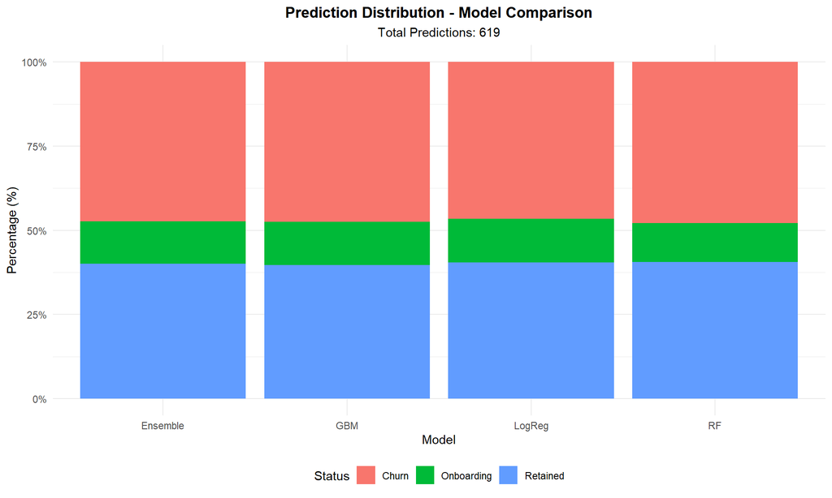

```
## ✓ Prediction distribution plot saved: test_prediction_distribution.png
```

```r
if (length(predictions_list) > 0) {
  # Combine prediction distributions
  plot_data <- data.frame()

  for (model_name in names(predictions_list)) {
    if (!is.null(predictions_list[[model_name]])) {
      temp_df <- data.frame(
        Model = model_name,
        Status = as.character(predictions_list[[model_name]])
      )
      plot_data <- rbind(plot_data, temp_df)
    }
  }

  # Add ensemble if exists
  if (exists("ensemble_predictions")) {
    ensemble_df_plot <- data.frame(
      Model = "Ensemble",
      Status = as.character(ensemble_predictions)
    )
    plot_data <- rbind(plot_data, ensemble_df_plot)
  }

  # Visualize
  if (nrow(plot_data) > 0) {
    p_dist <- ggplot(plot_data, aes(x = Model, fill = Status)) +
      geom_bar(position = "fill") +
      scale_y_continuous(labels = scales::percent) +
      labs(
        title = "Prediction Distribution - Model Comparison",
        subtitle = paste("Total Predictions:", length(test_customer_ids)),
        x = "Model",
        y = "Percentage (%)",
        fill = "Status"
      ) +
      theme_minimal() +
      theme(
        plot.title = element_text(hjust = 0.5, face = "bold"),
        plot.subtitle = element_text(hjust = 0.5),
        legend.position = "bottom"
      )

    print(p_dist)
    ggsave(file.path(PROJECT_DIR, "test_prediction_distribution.png"),
           plot = p_dist, width = 10, height = 6)

    cat("✓ Prediction distribution plot saved: test_prediction_distribution.png\n")
  }
}
```

# **14) Summary Report**

**Purpose:** Generate comprehensive summary statistics for all predictions.

```r
cat("\n", strrep("=", 60), "\n")
cat("TEST SUMMARY REPORT\n")
```

```
## TEST SUMMARY REPORT
```

```r
cat(strrep("=", 60), "\n")
cat("\nTEST DATA SUMMARY:\n")
```

```
##
## TEST DATA SUMMARY:
```

```r
cat("Total test customers:", length(test_customer_ids), "\n")
```

```
## Total test customers: 619
```

```r
cat("Total features:", ncol(test_final), "\n")
```

```
## Total features: 124
```

```r
cat("\nPREDICTION RESULTS:\n")
```

```
##
## PREDICTION RESULTS:
```

```r
for (model_name in names(predictions_list)) {
  if (!is.null(predictions_list[[model_name]])) {
    cat(sprintf("✓ %-20s: %d predictions\n", model_name, length(predictions_list[[model_name]])))

    # Prediction distribution
    pred_table <- table(predictions_list[[model_name]])
    for (status in names(pred_table)) {
      pct <- round(100 * pred_table[status] / sum(pred_table), 1)
      cat(sprintf("  - %s: %d (%.1f%%)\n", status, pred_table[status], pct))
    }
  } else {
    cat(sprintf("✗ %-20s: Failed\n", model_name))
  }
}
```

```
## ✓ RF                  : 619 predictions
##   - Churn: 296 (47.8%)
##   - Onboarding: 72 (11.6%)
##   - Retained: 251 (40.5%)
## ✓ LogReg              : 619 predictions
##   - Churn: 288 (46.5%)
##   - Onboarding: 81 (13.1%)
##   - Retained: 250 (40.4%)
## ✓ GBM                 : 619 predictions
##   - Churn: 294 (47.5%)
##   - Onboarding: 79 (12.8%)
##   - Retained: 246 (39.7%)
```

```r
if (exists("ensemble_predictions")) {
  cat("\n✓ Ensemble (Voting):", length(ensemble_predictions), "predictions\n")
  pred_table <- table(ensemble_predictions)
  for (status in names(pred_table)) {
    pct <- round(100 * pred_table[status] / sum(pred_table), 1)
    cat(sprintf("  - %s: %d (%.1f%%)\n", status, pred_table[status], pct))
  }
}
```

```
##
## ✓ Ensemble (Voting): 619 predictions
##   - Churn: 293 (47.3%)
##   - Onboarding: 78 (12.6%)
##   - Retained: 248 (40.1%)
```

```r
cat("\nCREATED FILES:\n")
```

```
##
## CREATED FILES:
```

```r
for (model_name in names(predictions_list)) {
  if (!is.null(predictions_list[[model_name]])) {
    cat(sprintf("- submission_%s.csv\n", model_name))
  }
}
```

```
## - submission_RF.csv
## - submission_LogReg.csv
## - submission_GBM.csv
```

```r
if (exists("ensemble_predictions")) {
  cat("- submission_ensemble.csv\n")
}
```

```
## - submission_ensemble.csv
```

```r
cat("- test_prediction_distribution.png\n")
```

```
## - test_prediction_distribution.png
```

```r
cat("\n", strrep("=", 60), "\n")
cat("✓ TEST PHASE SUCCESSFULLY COMPLETED!\n")
```

```
## ✓ TEST PHASE SUCCESSFULLY COMPLETED!
```

```r
cat(strrep("=", 60), "\n")
cat("\n✓ Completion Time:", Sys.time(), "\n")
```

```
##
## ✓ Completion Time: 1766977194
```

```r
cat("✓ Project Directory:", PROJECT_DIR, "\n")
```

```
## ✓ Project Directory: C:/Users/Bartu/Desktop/Customer_Status_Prediction
```

```r
cat("✓ Submission files are ready!\n")
```

```
## ✓ Submission files are ready!
```

# **15) Advanced Model Comparison**

**Purpose:** Perform detailed cross-model analysis to understand agreement patterns and prediction confidence.

```r
cat("\n", strrep("=", 60), "\n")
cat("STARTING CROSS-MODEL ANALYSIS...\n")
```

```
## STARTING CROSS-MODEL ANALYSIS...
```

```r
cat(strrep("=", 60), "\n")
```

```
##
## MODEL PREDICTION AGREEMENT RATES:
##   Model_A Model_B Matching_Records Agreement_Percentage
## 1      RF  LogReg              581                93.86
## 2      RF     GBM              598                96.61
## 3  LogReg     GBM              588                94.99
```

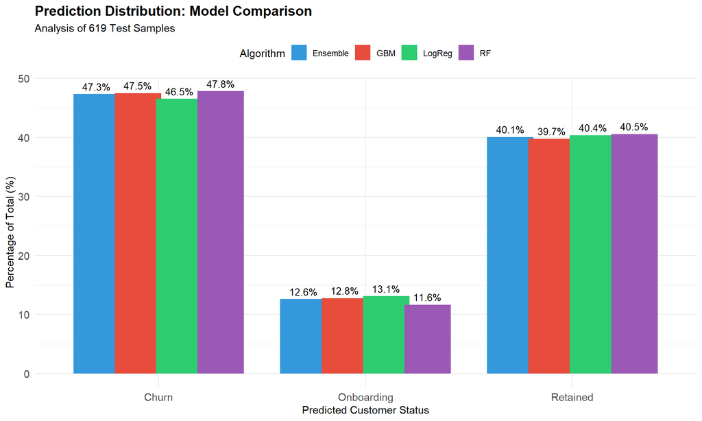

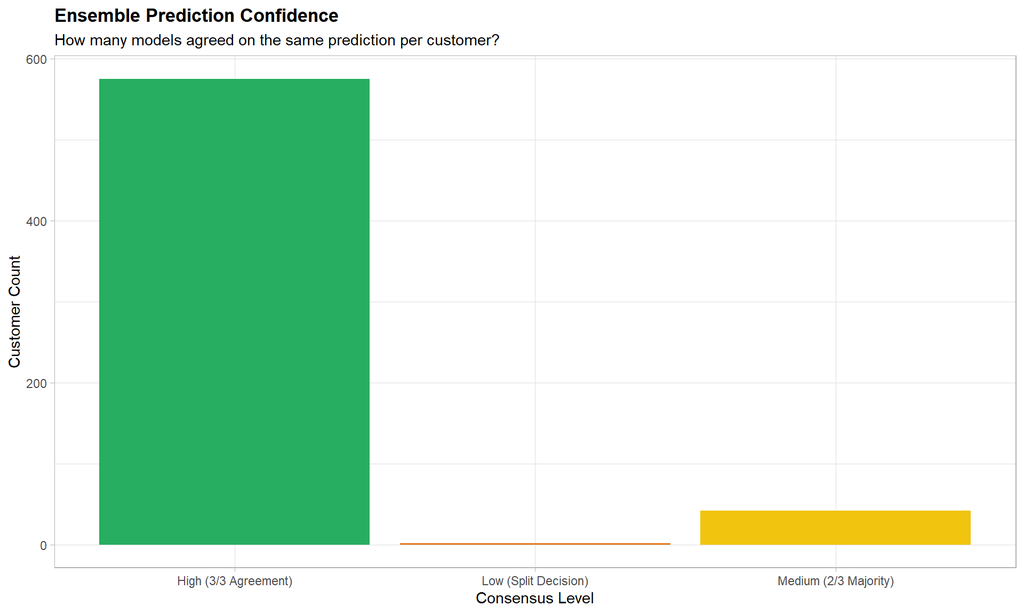

```r
if (length(available_models) >= 2 && exists("ensemble_df")) {

  # 15.1 Model Agreement Rate Table
  cat("\nMODEL PREDICTION AGREEMENT RATES:\n")

  agreement_results <- data.frame()

  for (i in 1:(length(available_models)-1)) {
    for (j in (i+1):length(available_models)) {
      m1 <- available_models[i]
      m2 <- available_models[j]

      agree_count <- sum(ensemble_df[[m1]] == ensemble_df[[m2]])
      agree_pct <- (agree_count / nrow(ensemble_df)) * 100

      agreement_results <- rbind(agreement_results, data.frame(
        Model_A = m1,
        Model_B = m2,
        Matching_Records = agree_count,
        Agreement_Percentage = round(agree_pct, 2)
      ))
    }
  }
  print(agreement_results)

  # 15.2 Side-by-Side Distribution Comparison
  plot_compare <- plot_data %>%
    group_by(Model, Status) %>%
    summarise(Count = n(), .groups = "drop") %>%
    group_by(Model) %>%
    mutate(Percentage = Count / sum(Count) * 100)

  p_compare <- ggplot(plot_compare, aes(x = Status, y = Percentage, fill = Model)) +
    geom_bar(stat = "identity", position = position_dodge(width = 0.8)) +
    geom_text(aes(label = sprintf("%.1f%%", Percentage)),
              position = position_dodge(width = 0.8), vjust = -0.5, size = 3.5) +
    scale_fill_manual(values = c("#3498db", "#e74c3c", "#2ecc71", "#9b59b6")) +
    labs(
      title = "Prediction Distribution: Model Comparison",
      subtitle = paste("Analysis of", length(test_customer_ids), "Test Samples"),
      x = "Predicted Customer Status",
      y = "Percentage of Total (%)",
      fill = "Algorithm"
    ) +
    theme_minimal() +
    theme(
      legend.position = "top",
      plot.title = element_text(face = "bold", size = 14),
      axis.text = element_text(size = 11)
    )

  print(p_compare)
  ggsave(file.path(PROJECT_DIR, "model_status_comparison.png"), p_compare, width = 10, height = 6)

  # 15.3 Decision Confidence Analysis
  if (length(available_models) == 3) {
    ensemble_df$Confidence <- apply(ensemble_df[, available_models], 1, function(x) {
      unique_votes <- length(unique(x))
      if (unique_votes == 1) return("High (3/3 Agreement)")
      if (unique_votes == 2) return("Medium (2/3 Majority)")
      return("Low (Split Decision)")
    })

    p_conf <- ggplot(ensemble_df, aes(x = Confidence, fill = Confidence)) +
      geom_bar() +
      scale_fill_manual(values = c("High (3/3 Agreement)" = "#27ae60",
                                   "Medium (2/3 Majority)" = "#f1c40f",
                                   "Low (Split Decision)" = "#e67e22")) +
      labs(
        title = "Ensemble Prediction Confidence",
        subtitle = "How many models agreed on the same prediction per customer?",
        x = "Consensus Level",
        y = "Customer Count"
      ) +
      theme_light() +
      theme(plot.title = element_text(face = "bold")) +
      guides(fill = "none")

    print(p_conf)
    ggsave(file.path(PROJECT_DIR, "ensemble_confidence.png"), p_conf, width = 8, height = 5)
  }
}
```

# **16) Final Summary Table**

**Purpose:** Create a tidy summary table of prediction counts by model and status.

```r
cat("\nFINAL PREDICTION SUMMARY TABLE:\n")
```

```
##
## FINAL PREDICTION SUMMARY TABLE:
```

```r
summary_stats <- plot_data %>%
  group_by(Model, Status) %>%
  summarise(n = n(), .groups = "drop") %>%
  pivot_wider(names_from = Status, values_from = n, values_fill = 0)

print(as.data.frame(summary_stats))
```

```
##      Model Churn Onboarding Retained
## 1 Ensemble   293         78      248
## 2      GBM   294         79      246
## 3   LogReg   288         81      250
## 4       RF   296         72      251
```

```r
cat("\n✓ Visual analysis and summary reports are ready in PROJECT_DIR.\n")
```

```
##
## ✓ Visual analysis and summary reports are ready in PROJECT_DIR.
```

# **Conclusion**

This analysis successfully:

1. ✅ Loaded pre-trained models (Random Forest, Logistic Regression, GBM)
2. ✅ Processed test data with identical transformations to training
3. ✅ Generated predictions from all models
4. ✅ Created individual submission files per model
5. ✅ Built ensemble predictions via majority voting
6. ✅ Analyzed model agreement and confidence
7. ✅ Produced comprehensive visualizations

**Output Files:** - `submission_RF.csv` - Random Forest predictions - `submission_LogReg.csv` - Logistic Regression predictions  
- `submission_GBM.csv` - Gradient Boosting predictions - `submission_ensemble.csv` - Ensemble (voting) predictions - `test_prediction_distribution.png` - Distribution visualization - `model_status_comparison.png` - Side-by-side comparison - `ensemble_confidence.png` - Consensus analysis